# Dataset.01: Spambase

What do the instances in this dataset represent?

- Emails

Additional Information

- The "spam" concept is diverse: advertisements for products/web sites, make money fast schemes, chain letters, pornography...
- The classification task for this dataset is to determine whether a given email is spam or not.
- Our collection of spam e-mails came from our postmaster and individuals who had filed spam. Our collection of non-spam e-mails came from filed work and personal e-mails, and hence the word 'george' and the area code '650' are indicators of non-spam. These are useful when constructing a personalized spam filter. One would either have to blind such non-spam indicators or get a very wide collection of non-spam to generate a general purpose spam filter.
- For background on spam: Cranor, Lorrie F., LaMacchia, Brian A. Spam!, Communications of the ACM, 41(8):74-83, 1998.
- Typical performance is around ~7% misclassification error. False positives (marking good mail as spam) are very undesirable.If we insist on zero false positives in the training/testing set, 20-25% of the spam passed through the filter. See also Hewlett-Packard Internal-only Technical Report. External version forthcoming.

```python
pip install ucimlrepo
```

```python
from ucimlrepo import fetch_ucirepo

# fetch dataset
spambase = fetch_ucirepo(id=94)

# data (as pandas dataframes)
X = spambase.data.features
y = spambase.data.targets
```

```python
X.columns = ['word_freq_make', 'word_freq_address', 'word_freq_all', 'word_freq_3d',
       'word_freq_our', 'word_freq_over', 'word_freq_remove',
       'word_freq_internet', 'word_freq_order', 'word_freq_mail',
       'word_freq_receive', 'word_freq_will', 'word_freq_people',
       'word_freq_report', 'word_freq_addresses', 'word_freq_free',
       'word_freq_business', 'word_freq_email', 'word_freq_you',
       'word_freq_credit', 'word_freq_your', 'word_freq_font', 'word_freq_000',
       'word_freq_money', 'word_freq_hp', 'word_freq_hpl', 'word_freq_george',
       'word_freq_650', 'word_freq_lab', 'word_freq_labs', 'word_freq_telnet',
       'word_freq_857', 'word_freq_data', 'word_freq_415', 'word_freq_85',
       'word_freq_technology', 'word_freq_1999', 'word_freq_parts',
       'word_freq_pm', 'word_freq_direct', 'word_freq_cs', 'word_freq_meeting',
       'word_freq_original', 'word_freq_project', 'word_freq_re',
       'word_freq_edu', 'word_freq_table', 'word_freq_conference',
       'char_freq_semicolon', 'char_freq_paranthesis', 'char_freq_bracket', 'char_freq_exc',
       'char_freq_dollar', 'char_freq_hashtag', 'capital_run_length_average',
       'capital_run_length_longest', 'capital_run_length_total']
print(len(X.columns))
```

```
57
```

There are 57 features in data. Feature names are updated as follows. They consist of some symbols.

```python
print(y.value_counts())
```

```
Class
0        2788
1        1813
Name: count, dtype: int64
```

Dataset requires a binary classification. It is, also, a bit imbalanced as counts can be seen as follows (5:3). Train set will be balanced after split.

```python
X.info()
```

```
<class 'pandas.core.frame.DataFrame'>
RangeIndex: 4601 entries, 0 to 4600
Data columns (total 57 columns):
 #   Column                      Non-Null Count  Dtype
---  ------                      --------------  -----
 0   word_freq_make              4601 non-null   float64
 1   word_freq_address           4601 non-null   float64
 2   word_freq_all               4601 non-null   float64
 3   word_freq_3d                4601 non-null   float64
 4   word_freq_our               4601 non-null   float64
 5   word_freq_over              4601 non-null   float64
 6   word_freq_remove            4601 non-null   float64
 7   word_freq_internet          4601 non-null   float64
 8   word_freq_order             4601 non-null   float64
 9   word_freq_mail              4601 non-null   float64
```

[output cut: 49 more lines]

```python
X.describe()
```

|  | word_freq_make | word_freq_address | word_freq_all | word_freq_3d | word_freq_our | word_freq_over | word_freq_remove | word_freq_internet | word_freq_order | word_freq_mail | ... | word_freq_conference | char_freq_semicolon | char_freq_paranthesis | char_freq_bracket | char_freq_exc | char_freq_dollar | char_freq_hashtag | capital_run_length_average | capital_run_length_longest | capital_run_length_total |
| --- | --- | --- | --- | --- | --- | --- | --- | --- | --- | --- | --- | --- | --- | --- | --- | --- | --- | --- | --- | --- | --- |
| count | 4601.000000 | 4601.000000 | 4601.000000 | 4601.000000 | 4601.000000 | 4601.000000 | 4601.000000 | 4601.000000 | 4601.000000 | 4601.000000 | ... | 4601.000000 | 4601.000000 | 4601.000000 | 4601.000000 | 4601.000000 | 4601.000000 | 4601.000000 | 4601.000000 | 4601.000000 | 4601.000000 |
| mean | 0.104553 | 0.213015 | 0.280656 | 0.065425 | 0.312223 | 0.095901 | 0.114208 | 0.105295 | 0.090067 | 0.239413 | ... | 0.031869 | 0.038575 | 0.139030 | 0.016976 | 0.269071 | 0.075811 | 0.044238 | 5.191515 | 52.172789 | 283.289285 |
| std | 0.305358 | 1.290575 | 0.504143 | 1.395151 | 0.672513 | 0.273824 | 0.391441 | 0.401071 | 0.278616 | 0.644755 | ... | 0.285735 | 0.243471 | 0.270355 | 0.109394 | 0.815672 | 0.245882 | 0.429342 | 31.729449 | 194.891310 | 606.347851 |
| min | 0.000000 | 0.000000 | 0.000000 | 0.000000 | 0.000000 | 0.000000 | 0.000000 | 0.000000 | 0.000000 | 0.000000 | ... | 0.000000 | 0.000000 | 0.000000 | 0.000000 | 0.000000 | 0.000000 | 0.000000 | 1.000000 | 1.000000 | 1.000000 |
| 25% | 0.000000 | 0.000000 | 0.000000 | 0.000000 | 0.000000 | 0.000000 | 0.000000 | 0.000000 | 0.000000 | 0.000000 | ... | 0.000000 | 0.000000 | 0.000000 | 0.000000 | 0.000000 | 0.000000 | 0.000000 | 1.588000 | 6.000000 | 35.000000 |
| 50% | 0.000000 | 0.000000 | 0.000000 | 0.000000 | 0.000000 | 0.000000 | 0.000000 | 0.000000 | 0.000000 | 0.000000 | ... | 0.000000 | 0.000000 | 0.065000 | 0.000000 | 0.000000 | 0.000000 | 0.000000 | 2.276000 | 15.000000 | 95.000000 |
| 75% | 0.000000 | 0.000000 | 0.420000 | 0.000000 | 0.380000 | 0.000000 | 0.000000 | 0.000000 | 0.000000 | 0.160000 | ... | 0.000000 | 0.000000 | 0.188000 | 0.000000 | 0.315000 | 0.052000 | 0.000000 | 3.706000 | 43.000000 | 266.000000 |
| max | 4.540000 | 14.280000 | 5.100000 | 42.810000 | 10.000000 | 5.880000 | 7.270000 | 11.110000 | 5.260000 | 18.180000 | ... | 10.000000 | 4.385000 | 9.752000 | 4.081000 | 32.478000 | 6.003000 | 19.829000 | 1102.500000 | 9989.000000 | 15841.000000 |

8 rows × 57 columns

```python
from sklearn.model_selection import train_test_split

X_train,X_test,y_train,y_test = train_test_split(X,y,test_size=0.3)
```

```python
from sklearn.preprocessing import StandardScaler
scaler = StandardScaler()
X_train = scaler.fit_transform(X_train)
X_test = scaler.transform(X_test)
```

```python
from imblearn.combine import SMOTEENN

cnt_before = y_train.value_counts()

X_train_os, y_train_os = SMOTEENN().fit_resample(X_train, y_train)

cnt_after = y_train_os.value_counts()
print(cnt_before, cnt_after)
```

```
Class
0        1913
1        1307
Name: count, dtype: int64 Class
1        1628
0        1513
Name: count, dtype: int64
```

## kNN

```python
import numpy as np
from sklearn.neighbors import KNeighborsClassifier
from sklearn.metrics import accuracy_score
```

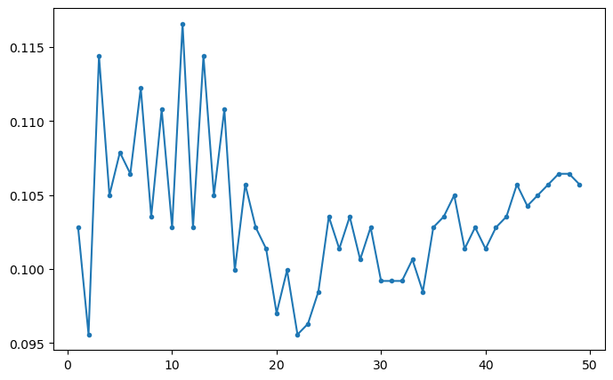

```python
import matplotlib.pyplot as plt
error_rate = []

for i in range(1,50):
    knn = KNeighborsClassifier(n_neighbors=i)
    knn.fit(X_train_os, y_train_os.values.ravel())
    y_pred_knn = knn.predict(X_test)
    error_rate.append(np.mean(y_pred_knn != y_test.values.ravel()))

plt.figure(figsize=(8,5))
plt.plot(range(1,50),error_rate, marker='o', markersize=3)
```

I selected 16 as n_neighbors.

```python
knn = KNeighborsClassifier(n_neighbors=16)
knn.fit(X_train_os, y_train_os.values.ravel())
y_pred_knn = knn.predict(X_test)
accuracy_score(y_test, y_pred_knn)
```

```
0.9000724112961622
```

## Decision Trees

```python
from sklearn.tree import DecisionTreeClassifier
```

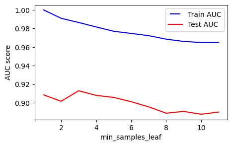

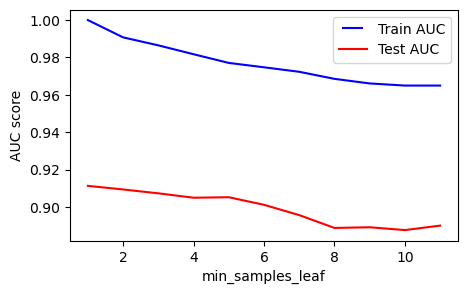

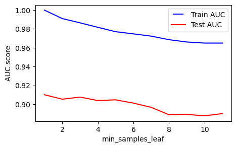

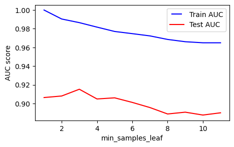

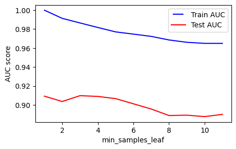

```python
from sklearn.metrics import roc_curve, auc

min_samples_leafs = np.linspace(1, 11, 11, dtype = int,endpoint=True)
for i in range(5):
    train_results = []
    test_results = []
    for min_samples_leaf in min_samples_leafs:
        dt = DecisionTreeClassifier(min_samples_leaf=min_samples_leaf)
        dt.fit(X_train_os, y_train_os)
        train_pred = dt.predict(X_train_os)
        false_positive_rate, true_positive_rate, thresholds = roc_curve(y_train_os, train_pred)
        roc_auc = auc(false_positive_rate, true_positive_rate)
        train_results.append(roc_auc)
        y_pred_dt = dt.predict(X_test)
        false_positive_rate, true_positive_rate, thresholds = roc_curve(y_test, y_pred_dt)
        roc_auc = auc(false_positive_rate, true_positive_rate)
        test_results.append(roc_auc)

    from matplotlib.legend_handler import HandlerLine2D
    plt.figure(figsize=(5, 3))
    line1, = plt.plot(min_samples_leafs, train_results, 'b', label='Train AUC')
    line2, = plt.plot(min_samples_leafs, test_results, 'r', label='Test AUC')
    plt.legend(handler_map={line1: HandlerLine2D(numpoints=2)})
    plt.ylabel('AUC score')
    plt.xlabel('min_samples_leaf')
    plt.show()
```

```python
dt = DecisionTreeClassifier(min_samples_leaf=5)
dt = dt.fit(X_train_os, y_train_os)
y_pred_dt = dt.predict(X_test)
accuracy_score(y_test, y_pred_dt)
```

```
0.9080376538740044
```

## Random Forests

```python
from sklearn.ensemble import RandomForestClassifier
from sklearn.metrics import mean_squared_error
```

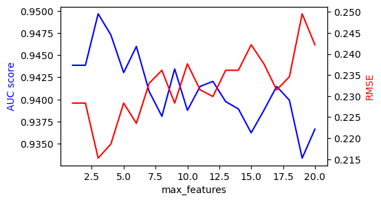

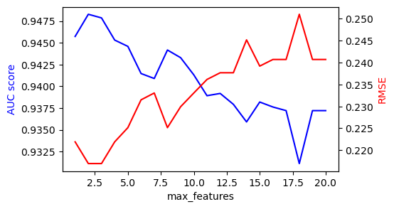

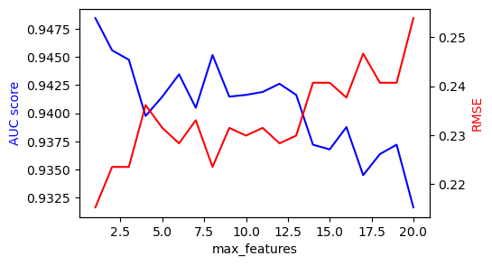

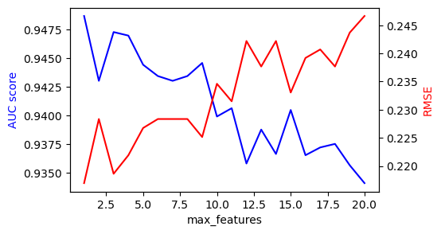

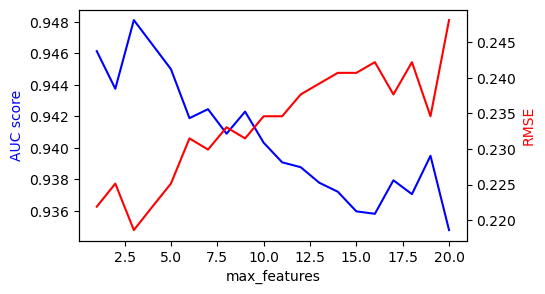

```python
max_features_n = np.linspace(1, 20, 20, dtype = int,endpoint=True) #57/3 = 19

for i in range(5):
    error_rate = []
    test_results = []
    for max_features in max_features_n:
        rf = RandomForestClassifier(max_features = max_features)
        rf.fit(X_train_os, y_train_os.values.ravel())
        y_pred_rf = rf.predict(X_test)
        false_positive_rate, true_positive_rate, thresholds = roc_curve(y_test, y_pred_rf)
        roc_auc = auc(false_positive_rate, true_positive_rate)
        test_results.append(roc_auc)
        rmse = np.sqrt(mean_squared_error(y_test, y_pred_rf))
        error_rate.append(rmse)

    fig, ax1 = plt.subplots(figsize=(5, 3))

    ax2 = ax1.twinx()
    ax1.plot(max_features_n, test_results, 'b', label='Test AUC')
    ax2.plot(max_features_n, error_rate, 'r', label='Test RMSE')

    ax1.set_xlabel('max_features')
    ax1.set_ylabel('AUC score', color='b')
    ax2.set_ylabel('RMSE', color='r')

    plt.show()
```

```python
rf = RandomForestClassifier(max_features = 9)
rf = rf.fit(X_train_os, y_train_os.values.ravel())
y_pred_rf = rf.predict(X_test)
accuracy_score(y_test, y_pred_rf)
```

```
0.946415640839971
```

## Gradient Boosted Trees

```python
from sklearn.ensemble import GradientBoostingClassifier
from xgboost import XGBClassifier
```

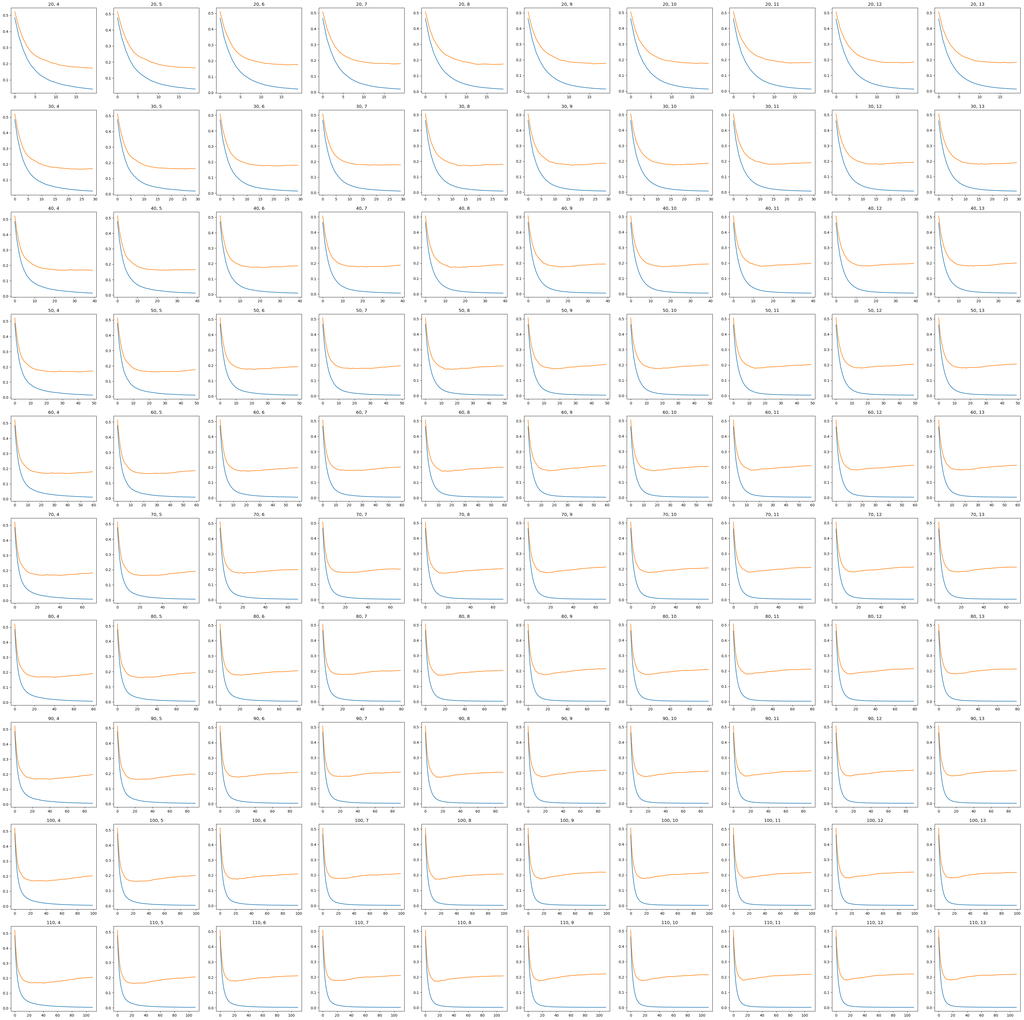

```python
fig, axs = plt.subplots(10, 10, figsize=(50, 50))
for i in range(10):
    for j in range(10):
        model = XGBClassifier(n_estimators = 20+10*i, max_depth = 4+j)
        evalset = [(X_train_os, y_train_os), (X_test,y_test)]
        model.fit(X_train_os, y_train_os, eval_set=evalset, verbose=False)
        model.set_params(eval_metric = 'logloss')
        y_pred_xgb = model.predict(X_test)
        score = accuracy_score(y_test, y_pred_xgb)
        results = model.evals_result()

        axs[i, j].plot(results['validation_0']['logloss'], label='train')
        axs[i, j].plot(results['validation_1']['logloss'], label='test')
        axs[i, j].set_title(str(20+10*i) + ', ' + str(4+j))
```

Initially I selected max_depth of 5 as charts imply that it has lower levels compared to higher max_depth values.

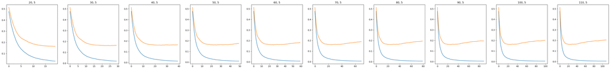

```python
fig, axs = plt.subplots(1, 10, figsize=(50, 5))
for i in range(10):
    model = XGBClassifier(n_estimators = 20+10*i, max_depth = 5)
    #evalset = [(X_train_os, y_train_os), (X_test,y_test)]
    model.fit(X_train_os, y_train_os, eval_set=evalset, verbose=False)
    model.set_params(eval_metric = 'logloss')
    y_pred_xgb = model.predict(X_test)
    score = accuracy_score(y_test, y_pred_xgb)
    results = model.evals_result()

    axs[i].plot(results['validation_0']['logloss'], label='train')
    axs[i].plot(results['validation_1']['logloss'], label='test')
    axs[i].set_title(str(20+10*i) + ', ' + str(5))
```

I select n_estimators of 50 since it starts to increase afterwards.

```python
xgb = XGBClassifier(n_estimators = 50, max_depth = 5)
xgb.fit(X_train_os, y_train_os.values.ravel())
y_pred_xgb = xgb.predict(X_test)
accuracy_score(y_test, y_pred_xgb)
```

```
0.9500362056480811
```

## Cross-validation

```python
from sklearn.model_selection import KFold
from sklearn.model_selection import cross_val_score
from numpy import mean
from numpy import absolute
from numpy import sqrt
cv = KFold(n_splits=10, random_state=1, shuffle=True)
for clf in [knn, dt, rf, xgb]:
    scores = cross_val_score(clf, X, y, scoring='neg_mean_absolute_error', cv=cv, n_jobs=-1)
    print(clf, ' : ', mean(absolute(scores)))
```

```
KNeighborsClassifier(n_neighbors=16)  :  0.21234744883523532
DecisionTreeClassifier(min_samples_leaf=5)  :  0.08780250872394604
RandomForestClassifier(max_features=9)  :  0.04564274262001321
XGBClassifier(base_score=None, booster=None, callbacks=None,
              colsample_bylevel=None, colsample_bynode=None,
              colsample_bytree=None, device=None, early_stopping_rounds=None,
              enable_categorical=False, eval_metric=None, feature_types=None,
              gamma=None, grow_policy=None, importance_type=None,
              interaction_constraints=None, learning_rate=None, max_bin=None,
              max_cat_threshold=None, max_cat_to_onehot=None,
              max_delta_step=None, max_depth=5, max_leaves=None,
              min_child_weight=None, missing=nan, monotone_constraints=None,
              multi_strategy=None, n_estimators=50, n_jobs=None,
              num_parallel_tree=None, random_state=None, ...)  :  0.0460756389701028
```

## Conclusion

```python
for clf in [[knn, y_pred_knn], [dt, y_pred_dt], [rf, y_pred_rf], [xgb, y_pred_xgb]]:
    print(clf[0], ' : ', accuracy_score(y_test, clf[1]))
```

```
KNeighborsClassifier(n_neighbors=16)  :  0.9000724112961622
DecisionTreeClassifier(min_samples_leaf=5)  :  0.9080376538740044
RandomForestClassifier(max_features=9)  :  0.946415640839971
XGBClassifier(base_score=None, booster=None, callbacks=None,
              colsample_bylevel=None, colsample_bynode=None,
              colsample_bytree=None, device=None, early_stopping_rounds=None,
              enable_categorical=False, eval_metric=None, feature_types=None,
              gamma=None, grow_policy=None, importance_type=None,
              interaction_constraints=None, learning_rate=None, max_bin=None,
              max_cat_threshold=None, max_cat_to_onehot=None,
              max_delta_step=None, max_depth=5, max_leaves=None,
              min_child_weight=None, missing=nan, monotone_constraints=None,
              multi_strategy=None, n_estimators=50, n_jobs=None,
              num_parallel_tree=None, random_state=None, ...)  :  0.9500362056480811
```